# **Milestone 1**

### **Income Vs Expenses**

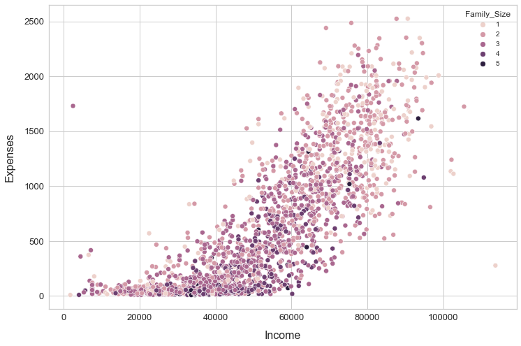

```python
# Plot the scatter plot with Expenses on Y-axis and Income on X-axis

plt.figure(figsize=(12, 8))                                    # Setting the plot size

sns.scatterplot(x='Income', y='Expenses', data=data, hue='Family_Size')            # Hint: Use sns.scatterplot()

plt.xticks(fontsize=13)                                         # Font size of X-label

plt.yticks(fontsize=13)                                         # Font size of Y-label

plt.xlabel("Income", fontsize=16, labelpad=12)                  # Title of X-axis

plt.ylabel("Expenses", fontsize=16, labelpad=12)                # Title of Y-axis

plt.show()
```

#### **Observations and Insights:**

- We can observe a positive correlation between **Income** and **Expenses**, which makes sense. The higher a customer's income, the higher they are likely to spend on groceries.

### **NumTotalPurchases Vs Expenses**

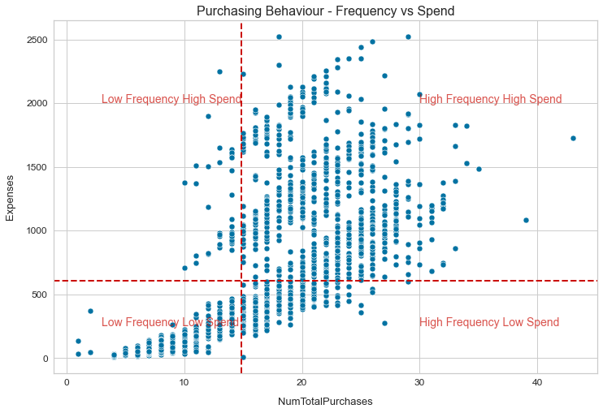

```python
# Plot the scatter plot with Expenses on Y-axis and Income on X-axis

plt.figure(figsize=(12, 8))                                    # Setting the plot size

sns.scatterplot(x='NumTotalPurchases', y='Expenses', data=data)            # Hint: Use sns.scatterplot()

#Title
plt.title(f"Purchasing Behaviour - Frequency vs Spend", fontsize=16)

plt.xticks(fontsize=12)                                         # Font size of X-label

plt.yticks(fontsize=12)                                         # Font size of Y-label

plt.xlabel("NumTotalPurchases", fontsize=13, labelpad=13)                  # Title of X-axis

plt.ylabel("Expenses", fontsize=13, labelpad=13)                # Title of Y-axis

#Quadrant Marker
plt.text(x=30, y=250, s="High Frequency Low Spend",alpha=0.7, fontsize=14, color='r')
plt.text(x=3, y=250, s="Low Frequency Low Spend",alpha=0.7, fontsize=14, color='r')
plt.text(x=3, y=2000, s="Low Frequency High Spend", alpha=0.7, fontsize=14, color='r')
plt.text(x=30, y=2000, s="High Frequency High Spend", alpha=0.7, fontsize=14, color='r')

# Benchmark Mean values
plt.axhline(y=data['Expenses'].mean(), color='r', linestyle='--', linewidth=2)
plt.axvline(x=data['NumTotalPurchases'].mean(), color='r',linestyle='--', linewidth=2)

plt.show()
```

Here we can see the plot between **NumTotalPurchases** - between high frequency and low frequency clients and their spending.

### **Family Size Vs Income**

```
AxesSubplot(0.125,0.125;0.775x0.755)
```

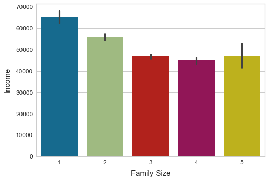

```python
# Plot the bar plot for Family Size on X-axis and Income on Y-axis

print(sns.barplot(x= 'Family_Size', y= 'Income', data=data, ci = 95))
plt.xticks(fontsize=12)                                         # Font size of X-label
plt.yticks(fontsize=12)                                         # Font size of Y-label
plt.xlabel("Family Size", fontsize=15, labelpad=10)             # Title of X-axis
plt.ylabel("Income", fontsize=15, labelpad=10)                  # Title of Y-axis
```

```python
data['Family_Size'].value_counts()
```

```
3    886
2    756
4    300
1    252
5     32
Name: Family_Size, dtype: int64
```

#### **Observations and Insights:**

**After data preprocessing and data cleaning, let's create a new correlation matrix with the new variables.**

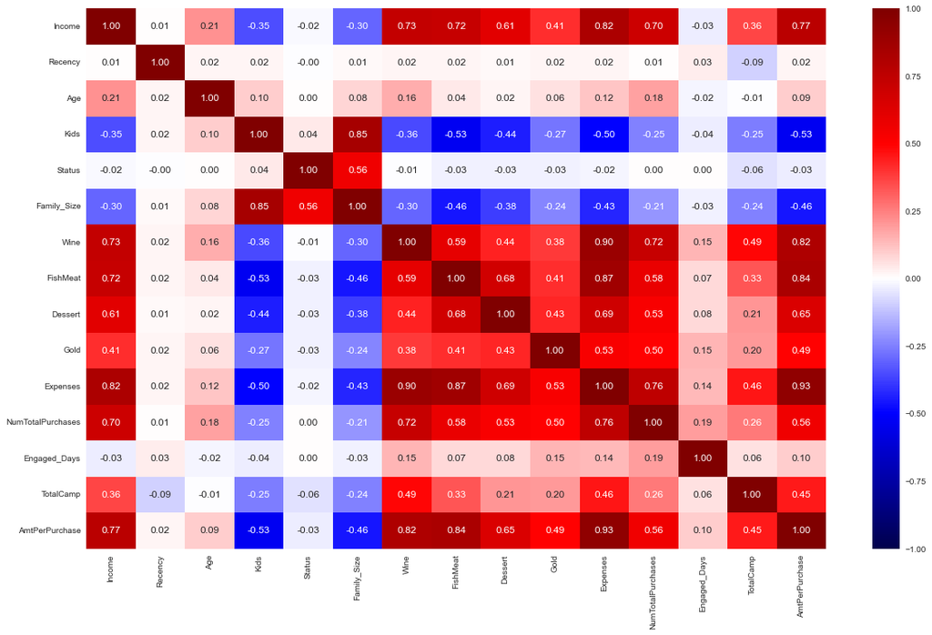

```python
#Create a new column list with the new variables with numerical variables to plot a correlation matrix
cols_list_3 = data.select_dtypes(include = np.number).columns.tolist()

cols_list_3 = [
 'Income',
 'Recency',
 'Age',
 'Kids',
 'Status',
 'Family_Size',
 'Wine',
 'FishMeat',
 'Dessert',
 'Gold',
 'Expenses',
 'NumTotalPurchases',
 'Engaged_Days',
 'TotalCamp',
 'AmtPerPurchase']

#Plotsize
plt.figure(figsize=(20, 12))

 # Plotting the correlation plot
sns.heatmap(
    data[cols_list_3].corr(), annot=True, vmin=-1, vmax=1, fmt=".2f", cmap="seismic"
)

plt.show()
```

**Observations and Insights:**

## **Proposed approach**

- **Potential techniques -** What different techniques should be explored?
- **Overall solution design -** What is the potential solution design?
- **Measures of success -** What are the key measures of success?

# **Customer Segmentation**

```python
data.shape
```

```
(2226, 38)
```

## Preparing Data for Segmentation

### Dropping columns that we will not use for segmentation

The decision about which variables to use for clustering is a critically important decision that will have a big impact on the clustering solution. So we need to think carefully about the variables we will choose for clustering. Clearly, this is a step where a lot of contextual knowledge, creativity, and experimentation/iterations are needed.

Moreover, we often use only a few of the data attributes for segmentation (the segmentation attributes) and use some of the remaining ones (the profiling attributes) only to profile the clusters. For example, in market research and market segmentation, we can use behavioral data for segmentation (to segment the customers based on their behavior like amount spent, units bought, etc.), and then use both demographic as well as behavioral data for profiling the segments found.

Here, we will use the behavioral attributes for segmentation and drop the demographic attributes like `Income`, `Age`, and `Family_Size`. In addition to this, we need to drop some other columns which are mentioned below.

- `Dt_Customer`: We have created the `Engaged_in_days` variable using the Dt_Customer variable. Hence, we can drop this variable as it will not help with segmentation.
- `Complain`: About 95% of the customers didn't complain and have the same value for this column. This variable will not have a major impact on segmentation. Hence, we can drop this variable.
- `day`: We have created the `Engaged_in_days` variable using the 'day' variable. Hence, we can drop this variable as it will not help with segmentation.
- `Status`: This column was created just to get the `Family_Size` variable that contains the information about the Status. Hence, we can drop this variable.
- We also need to drop categorical variables like `Education` and `Marital_Status`, `Kids`, `Kidhome`, and `Teenhome` as distance-based algorithms cannot use the default distance like Euclidean to find the distance between categorical and numerical variables.
- We can also drop categorical variables like `AcceptedCmp1`, `AcceptedCmp2`, `AcceptedCmp3`, `AcceptedCmp4`, `AcceptedCmp5`, and `Response` for which we have create the variable `TotalAcceptedCmp` which is the aggregate of all these variables.
- We can drop the individual `Fish` and `Meat` column since we have combined them into `FishMeat`
- We can drop the individual `Sweets` and `Fruits` column since we have combined them into `Dessert`

```python
data.columns
```

```
Index(['Year_Birth', 'Education', 'Marital_Status', 'Income', 'Kidhome',
       'Teenhome', 'Dt_Customer', 'Recency', 'Wine', 'Fruits', 'Meat', 'Fish',
       'Sweets', 'Gold', 'NumDealsPurchases', 'NumWebPurchases',
       'NumCatalogPurchases', 'NumStorePurchases', 'NumWebVisitsMonth',
       'Camp3', 'Camp4', 'Camp5', 'Camp1', 'Camp2', 'Complain', 'Camp6', 'Age',
       'Kids', 'Status', 'Family_Size', 'Expenses', 'NumTotalPurchases', 'day',
       'Engaged_Days', 'FishMeat', 'Dessert', 'TotalCamp', 'AmtPerPurchase'],
      dtype='object')
```

```python
# Dropping all the irrelevant columns and storing in data_model
data_model = data.drop(
    columns=[
        "Year_Birth",
        "Dt_Customer",
        "day",
        "Complain",
        "Camp6",
        "Camp1",
        "Camp2",
        "Camp3",
        "Camp4",
        "Camp5",
        "Marital_Status",
        "Status",
        "Kids",
        'Education',
        'Kidhome',
        'Teenhome',
        'Income',
        'Age',
        'Family_Size',
        'Fish',
        'Meat',
        'Sweets',
        'Fruits',
    ],
    axis=1,
)
```

```python
#Setting columns in a particular order and grouping
data_model = data_model[['Expenses',
                         'NumTotalPurchases',
                         'AmtPerPurchase',
                         'TotalCamp',
                         'Recency',
                         'Engaged_Days',
                         'NumStorePurchases',
                         'NumCatalogPurchases',
                         'NumWebPurchases',
                         'NumDealsPurchases',
                         'NumWebVisitsMonth',
                         'Wine',
                         'FishMeat',
                         'Dessert',
                         'Gold'
                        ]]
```

```python
# Check the shape of new data
data_model.shape
```

```
(2226, 15)
```

```python
data_model.info()
```

```
<class 'pandas.core.frame.DataFrame'>
Int64Index: 2226 entries, 0 to 2239
Data columns (total 15 columns):
 #   Column               Non-Null Count  Dtype
---  ------               --------------  -----
 0   Expenses             2226 non-null   int64
 1   NumTotalPurchases    2226 non-null   int64
 2   AmtPerPurchase       2226 non-null   float64
 3   TotalCamp            2226 non-null   int64
 4   Recency              2226 non-null   int64
 5   Engaged_Days         2226 non-null   int64
 6   NumStorePurchases    2226 non-null   int64
 7   NumCatalogPurchases  2226 non-null   int64
 8   NumWebPurchases      2226 non-null   int64
 9   NumDealsPurchases    2226 non-null   int64
 10  NumWebVisitsMonth    2226 non-null   int64
 11  Wine                 2226 non-null   int64
 12  FishMeat             2226 non-null   int64
 13  Dessert              2226 non-null   int64
 14  Gold                 2226 non-null   int64
dtypes: float64(1), int64(14)
memory usage: 278.2 KB
```

```python
# Check first five rows of new data
data_model.head()
```

|  | Expenses | NumTotalPurchases | AmtPerPurchase | TotalCamp | Recency | Engaged_Days | NumStorePurchases | NumCatalogPurchases | NumWebPurchases | NumDealsPurchases | NumWebVisitsMonth | Wine | FishMeat | Dessert | Gold |
| --- | --- | --- | --- | --- | --- | --- | --- | --- | --- | --- | --- | --- | --- | --- | --- |
| 0 | 1617 | 25 | 64.680000 | 1 | 58 | 997 | 4 | 10 | 8 | 3 | 7 | 635 | 718 | 176 | 88 |
| 1 | 27 | 6 | 4.500000 | 0 | 38 | 151 | 2 | 1 | 1 | 2 | 5 | 11 | 8 | 2 | 6 |
| 2 | 776 | 21 | 36.952381 | 0 | 26 | 498 | 10 | 2 | 8 | 1 | 4 | 426 | 238 | 70 | 42 |
| 3 | 53 | 8 | 6.625000 | 0 | 26 | 91 | 4 | 0 | 2 | 2 | 6 | 11 | 30 | 7 | 5 |
| 4 | 422 | 19 | 22.210526 | 0 | 94 | 347 | 6 | 3 | 5 | 5 | 5 | 173 | 164 | 70 | 15 |

```python
data_model.describe().T
```

|  | count | mean | std | min | 25% | 50% | 75% | max |
| --- | --- | --- | --- | --- | --- | --- | --- | --- |
| Expenses | 2226.0 | 605.597934 | 600.737270 | 8.000000 | 69.000000 | 397.000000 | 1043.750000 | 2525.0 |
| NumTotalPurchases | 2226.0 | 14.888589 | 7.608581 | 1.000000 | 8.000000 | 15.000000 | 21.000000 | 43.0 |
| AmtPerPurchase | 2226.0 | 32.534950 | 28.491805 | 0.533333 | 9.714286 | 23.348346 | 45.185102 | 186.5 |
| TotalCamp | 2226.0 | 0.448338 | 0.890539 | 0.000000 | 0.000000 | 0.000000 | 1.000000 | 5.0 |
| Recency | 2226.0 | 49.114555 | 28.958923 | 0.000000 | 24.000000 | 49.000000 | 74.000000 | 99.0 |
| Engaged_Days | 2226.0 | 538.116801 | 232.276365 | 26.000000 | 367.000000 | 539.000000 | 712.000000 | 1089.0 |
| NumStorePurchases | 2226.0 | 5.819856 | 3.238030 | 0.000000 | 3.000000 | 5.000000 | 8.000000 | 13.0 |
| NumCatalogPurchases | 2226.0 | 2.640162 | 2.796368 | 0.000000 | 0.000000 | 2.000000 | 4.000000 | 28.0 |
| NumWebPurchases | 2226.0 | 4.105571 | 2.773242 | 0.000000 | 2.000000 | 4.000000 | 6.000000 | 27.0 |
| NumDealsPurchases | 2226.0 | 2.323001 | 1.894612 | 0.000000 | 1.000000 | 2.000000 | 3.000000 | 15.0 |
| NumWebVisitsMonth | 2226.0 | 5.328841 | 2.399933 | 0.000000 | 3.000000 | 6.000000 | 7.000000 | 20.0 |
| Wine | 2226.0 | 305.386343 | 336.816488 | 0.000000 | 24.000000 | 177.500000 | 505.000000 | 1493.0 |
| FishMeat | 2226.0 | 202.471249 | 253.778850 | 1.000000 | 22.000000 | 80.000000 | 306.000000 | 1726.0 |
| Dessert | 2226.0 | 53.578616 | 71.806096 | 0.000000 | 5.000000 | 19.000000 | 76.000000 | 378.0 |
| Gold | 2226.0 | 44.161725 | 52.108201 | 0.000000 | 9.000000 | 25.000000 | 56.750000 | 362.0 |

```python
data_model.skew()
```

```
Expenses               0.862807
NumTotalPurchases      0.234591
AmtPerPurchase         1.320231
TotalCamp              2.420412
Recency               -0.005882
Engaged_Days           0.004725
NumStorePurchases      0.710701
NumCatalogPurchases    1.369995
NumWebPurchases        1.391684
NumDealsPurchases      2.322283
NumWebVisitsMonth      0.193251
Wine                   1.170403
FishMeat               1.602253
Dessert                1.722148
Gold                   1.880374
dtype: float64
```

We will use these **15 features** to apply to our **clustering algorithms**

**Let's plot the correlation plot after we've removed the irrelevant variables.**

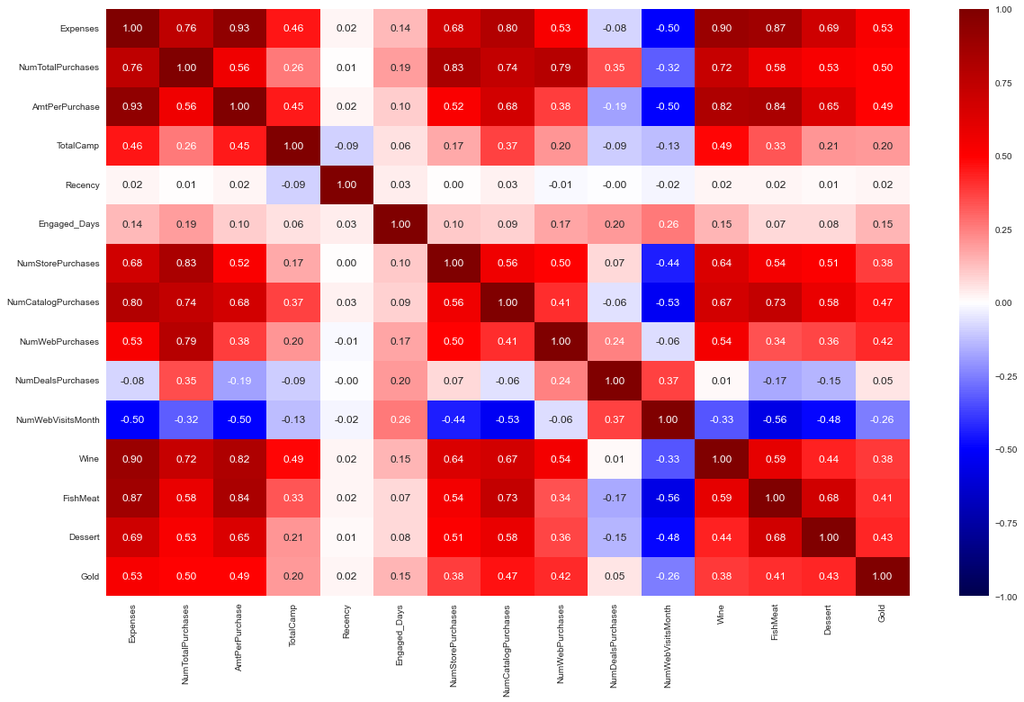

```python
# Plot the correlation plot for new data
#Plotsize
plt.figure(figsize=(20, 12))

 # Plotting the correlation plot
sns.heatmap(data_model.corr(), annot=True, vmin=-1, vmax=1, fmt=".2f", cmap="seismic")


plt.show()
```

**Observations and Insights:**

With these new variables -

- We can see a **high positive correlation** between:
  - **Expenses** and **AmtPerPurchase (0.93)**/**NumTotalPurchases (0.76)**, which makes sense
  - **Expenses** and **NumCatalogPurchases (0.80)**, the highest amongst the channels.
  - **Expenses** has the highest correlation amongst **Wine (0.90)** and **FishMeat (0.87)** amongst the product categories
  - **NumTotalPurchases** and **Wine (0.72)** - being the highest, vs the other products in the 0.50.
  - **NumTotalPurchases** and **NumStorePurchases (0.83)**, **NumWebPurchases (0.79)**, **NumCatalogPurchase (0.74)** compared to **Expenses** has highest correlation with **Catalog (0.80)** purchases amongst the different retail channels.
- There is no correlation between **Recency** and any of the variables.
- There is very low correlation between **Engaged_Days** and any of the variables.
- We can see a **negative correlation** between:
  - **NumWebVisits** and all the product categories, as well as **Catalog** and **Store** purchases. (though positively correlated with **NumDealPurchases** suggesting that customers tend to look online for discounts.

### Scaling the Data

**What is feature scaling?**

Feature scaling is a class of statistical techniques that, as the name implies, scales the features of our data so that they all have a similar range. You'll understand better if we look at an example:

If you have multiple independent variables like Age, Income, and Amount related variables, with their range as (18–100 Years), (25K–75K), and (100–200), respectively, feature scaling would help them all to be in the same range.

**Why feature scaling is important in Unsupervised Learning?**

Feature scaling is especially relevant in machine learning models that compute some sort of distance metric as we do in most clustering algorithms, for example, K-Means.

So, scaling should be done to avoid the problem of one feature dominating over others because the unsupervised learning algorithm uses distance to find the similarity between data points.

**Let's scale the data**

**Standard Scaler**: StandardScaler standardizes a feature by subtracting the mean and then scaling to unit variance. Unit variance means dividing all the values by the standard deviation.

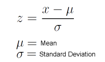

1. Data standardization is the process of rescaling the attributes so that they have a mean of 0 and a variance of 1.
2. The ultimate goal to perform standardization is to bring down all the features to a common scale without distorting the differences in the range of the values.
3. In sklearn.preprocessing.StandardScaler(), centering and scaling happen independently on each feature.

```python
# Applying standard scaler on new data

# Initialize the Standard Scaler
scaler = StandardScaler()

# fit_transform the scaler function on new data
df_scaled = scaler.fit_transform(data_model)

# Converting the embeddings to a dataframe
df_scaled = pd.DataFrame(df_scaled, columns=data_model.columns)

df_scaled.head()
```

|  | Expenses | NumTotalPurchases | AmtPerPurchase | TotalCamp | Recency | Engaged_Days | NumStorePurchases | NumCatalogPurchases | NumWebPurchases | NumDealsPurchases | NumWebVisitsMonth | Wine | FishMeat | Dessert | Gold |
| --- | --- | --- | --- | --- | --- | --- | --- | --- | --- | --- | --- | --- | --- | --- | --- |
| 0 | 1.683980 | 1.329247 | 1.128474 | 0.619609 | 0.306898 | 1.976035 | -0.562152 | 2.632519 | 1.404603 | 0.357409 | 0.696492 | 0.978835 | 2.031866 | 1.705272 | 0.841482 |
| 1 | -0.963363 | -1.168495 | -0.984186 | -0.503558 | -0.383890 | -1.666996 | -1.179950 | -0.586665 | -1.120085 | -0.170522 | -0.137052 | -0.874222 | -0.766474 | -0.718466 | -0.732520 |
| 2 | 0.283719 | 0.803407 | 0.155077 | -0.503558 | -0.798364 | -0.172750 | 1.291243 | -0.228978 | 1.404603 | -0.698453 | -0.553824 | 0.358179 | 0.140030 | 0.228742 | -0.041495 |
| 3 | -0.920073 | -0.905575 | -0.909587 | -0.503558 | -0.798364 | -1.925367 | -0.562152 | -0.944352 | -0.759416 | -0.170522 | 0.279720 | -0.874222 | -0.679765 | -0.648818 | -0.751715 |
| 4 | -0.305690 | 0.540486 | -0.362446 | -0.503558 | 1.550318 | -0.822984 | 0.055646 | 0.128710 | 0.322594 | 1.413271 | -0.137052 | -0.393140 | -0.151628 | 0.228742 | -0.559764 |

## **Applying T-SNE and PCA to the data to visualize the data distributed in 2 dimensions**

### **Applying T-SNE**

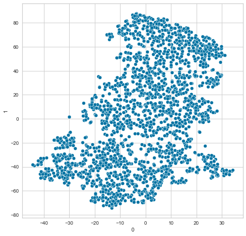

```python
# Fitting T-SNE with number of components equal to 2 to visualize how data is distributed

tsne = TSNE(n_components = 2, random_state = 1, perplexity = 35)   # Initializing T-SNE with number of component equal to 2, random_state=1, and perplexity=35

data_tsne = tsne.fit_transform(df_scaled)                          # fit_transform T-SNE on new data

data_tsne = pd.DataFrame(data_tsne, columns=[0, 1])                # Converting the embeddings to a dataframe

plt.figure(figsize=(8, 8))                                         # Scatter plot for two components

sns.scatterplot(x=0, y=1, data=data_tsne)                          # Plotting T-SNE
```

**Observation and Insights:**

The axis has no labels in t-SNE - it tries to match the distributions against each other.

We see that there is no defined pattern from t-SNE. It looks like an undefined cloud, with not very separated clusters. Hence, **t-SNE does not give us any revelations about underlying clusters in the data**

Let's try PCA instead.

### **Applying PCA**

**Think about it:**

- Should we apply clustering algorithms on the current data or should we apply PCA on the data before applying clustering algorithms? How would this help?

To avoid the curse of dimensionality, we can first apply PCA analysis on our dataset before applying clustering algorithms. PCA is a dimensionality reduction technique used on large datasets. It tries to find the direction in which the data spreads out the most. So the PC1 is the direction of the largest variance, PC2, which is orthogonal to PC1, is the 2nd largest spread of the data and so on.

When the variables used in clustering are highly correlated, it causes multicollinearity, which affects the clustering method and results in poor cluster profiling (or biased toward a few variables). PCA can be used to reduce the multicollinearity between the variables.

```python
# Defining the number of principal components to generate
n = data_model.shape[1]                                        # Storing the number of variables in the data

pca = PCA(n_components = n, random_state = 1)                  # Initialize PCA with n_components = n and random_state=1

data_pca = pd.DataFrame(pca.fit_transform(data_model))         # fit_transform PCA on the scaled data

# The percentage of variance explained by each principal component is stored
exp_var = pca.explained_variance_ratio_
```

```python
# Finding the least number of components that can explain more than 90% variance
sum = 0

for ix, i in enumerate(exp_var):
    sum = sum + i
    if(sum>0.90):
        print("Number of PCs that explain at least 90% variance: ", ix + 1)
        break
```

```
Number of PCs that explain at least 90% variance:  2
```

Out of the original 15 features, we have reduced the number of features through PCA to 2 principal components. The first **2** principal components explain more than **90% of the original variance**, an **87% reduction in the dimensionality of the dataset with only a loss of 10% in variance**.

```python
data_model.columns
```

```
Index(['Expenses', 'NumTotalPurchases', 'AmtPerPurchase', 'TotalCamp',
       'Recency', 'Engaged_Days', 'NumStorePurchases', 'NumCatalogPurchases',
       'NumWebPurchases', 'NumDealsPurchases', 'NumWebVisitsMonth', 'Wine',
       'FishMeat', 'Dessert', 'Gold'],
      dtype='object')
```

```python
pc_comps = ['PC1', 'PC2']

data_pca_1 = pd.DataFrame(np.round(pca.components_[:2,:], 2), index = pc_comps, columns = data_pca.columns)

data_pca_1.T

def color_high(val):
    if val <= -0.30:
        return 'background: pink'

    elif val >= 0.30:
        return 'background: skyblue'

data_pca_1.style.applymap(color_high)
```

|  | 0 | 1 | 2 | 3 | 4 | 5 | 6 | 7 | 8 | 9 | 10 | 11 | 12 | 13 | 14 |
| --- | --- | --- | --- | --- | --- | --- | --- | --- | --- | --- | --- | --- | --- | --- | --- |
| PC1 | 0.840000 | 0.010000 | 0.040000 | 0.000000 | 0.000000 | 0.050000 | 0.000000 | 0.000000 | 0.000000 | -0.000000 | -0.000000 | 0.430000 | 0.310000 | 0.070000 | 0.040000 |
| PC2 | 0.050000 | -0.000000 | 0.010000 | -0.000000 | -0.000000 | -0.990000 | -0.000000 | 0.000000 | -0.000000 | -0.000000 | -0.000000 | -0.090000 | 0.130000 | 0.020000 | -0.010000 |

Each principal component is a linear combination of the original features.

**PC1** is the direction of largest variance, where the data spreads the most. **PC2** is orthogonal to PC1 and is the direction of the next largest variance.

- In these results, the **first principal component (PC1**) has large positive associations with `Expenses` and `Wine`, and to a lesser extent, `FishMeat` purchase. We can interpret this component to be primarily a measure of a customer's expenditure at the store, since we see the high correlation between these variables above in the correlation matrix.
- The **second principal component (PC2)**, where the data spreads the 2nd most, has a large negative association with `Engaged_Days` - how long a customer has been a purchasing from the company.

**Let's plot the first two components and see how the data points are distributed.**

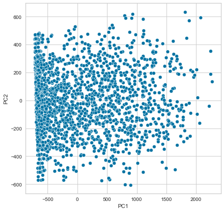

```python
# Scatter plot for two components using the dataframe data_pca
plt.figure(figsize = (7, 7))

sns.scatterplot(x = data_pca[0], y = data_pca[1])

plt.xlabel("PC1")

plt.ylabel("PC2")

plt.show()
```

**Let's apply clustering algorithms on the data generated after applying PCA**

## **Clustering Algorithms**

**The following four types are the most widely used types of clustering models:**

- **Centroid Model:** uses the distance between a data point and the centroid of the cluster to group data.
  - K-means is an example of a centroid model.
  - K-medoids is another
- **Connectivity Model:** uses the closeness of the data points to decide the clusters.
  - Hierarchical Clustering Model is a widely used connectivity model.
- **Density Model:** scans the data space and assigns clusters based on the density of data points.
  - DBSCAN (Density-Based Spatial Clustering of Applications with Noise) is a popular density model
- **Distribution Model:** segments data based on their probability of belonging to the same distribution.
  - Gaussian Mixture Model (GMM) is a popular distribution model.

We will go through each of these to find the best solution for our dataset

## **K-Means**

```python
distortions = []                                                  # Create an empty list

K = range(2, 10)                                                  # Setting the K range from 2 to 10

for k in K:
    kmeanModel = KMeans(n_clusters=k, init = 'k-means++', random_state=4)   # Initialize K-Means

    kmeanModel.fit(data_pca)                                      # Fit K-Means on the data

    distortions.append(kmeanModel.inertia_)                       # Append distortion values to the empty list created above
```

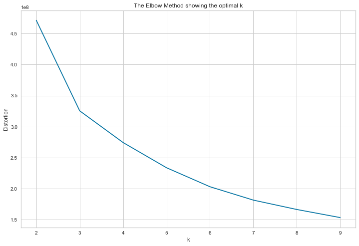

```python
# Plotting the elbow plot
plt.figure(figsize=(12, 8))                                            # Setting the plot size

plt.plot(K, distortions, "bx-")                                        # Plotting the K on X-axis and distortions on y-axis

plt.xlabel("k")                                                        # Title of x-axis

plt.ylabel("Distortion")                                               # Title of y-axis

plt.title("The Elbow Method showing the optimal k")                    # Title of the plot
plt.show()
```

**In the above plot, the elbow is seen most obviously for K=3. But also K=4, and K=5 as there is some drop in distortion at K=4 and K=5.**

It is not obvious from the Elbow Method to determine the optimal K value.

Hence, we will cross-reference this with the Silhouette Score

**Think About It:**

- How do we determine the optimal K value when the elbows are observed at 2 or more K values from the elbow curve?
- Which metric can be used to determine the final K value?

**We can use the silhouette score as a metric for different K values to make a better decision about picking the number of clusters (K).**

### **What is the silhouette score?**

Silhouette score is one of the methods for evaluating the quality of clusters created using clustering algorithms such as K-Means. The silhouette score is a measure of how similar an object is to its cluster (cohesion) compared to other clusters (separation). Silhouette score has a range of [-1, 1].

- Silhouette coefficients near +1 indicate that the clusters are dense and well separated, which is good.
- Silhouette score near -1 indicates that those samples might have been assigned to the wrong cluster.

**Finding silhouette score for each value of K**

```python
#Creating empty list
sil_score = []

#Creating a range from 3 to 7
cluster_list = range(3, 7)

for n_clusters in cluster_list:

    # Initialize K-Means with number of clusters equal to n_clusters and random_state=1
    clusterer = KMeans(n_clusters=n_clusters, random_state = 1).fit(data_pca)

    # Fit and predict on the pca data
    preds = clusterer.predict(data_pca)

    # Calculate silhouette score - Hint: Use silhouette_score() function
    score = silhouette_score(data_pca, preds)

    # Append silhouette score to empty list created above
    sil_score.append(score)

    # Print the silhouette score
    print( "For n_clusters = {}, the silhouette score is {})".format(n_clusters, score))
```

```
For n_clusters = 3, the silhouette score is 0.4743850857345939)
For n_clusters = 4, the silhouette score is 0.38208923239756326)
For n_clusters = 5, the silhouette score is 0.33591075163090683)
For n_clusters = 6, the silhouette score is 0.33947881552706566)
```

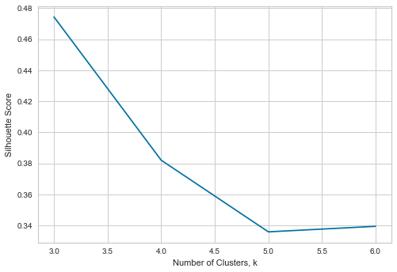

```python
from sklearn.metrics import silhouette_score

# Empty dictionary to store the Silhouette score for each value of K
sc = {}

# Iterate for a range of Ks and fit the scaled data to the algorithm. Store the Silhouette score for that K
for k in range(3, 7):
    kmeans = KMeans(n_clusters = k, random_state = 1).fit(data_model)

    labels = kmeans.predict(data_model)

    sc[k] = silhouette_score(data_model, labels)

# Elbow plot
plt.figure()

plt.plot(list(sc.keys()), list(sc.values()), 'bx-')

plt.xlabel("Number of Clusters, k")

plt.ylabel("Silhouette Score")

plt.show()
```

**From the above silhouette scores, 3 returns the highest value. But 4 gives us a lower Within-Group-Sum-of-Square measure. So we will try K-Means on both k=3 and k=4 to find better insights**

### **Applying K-Means on data_pca**

```python
# Initialize the K-Means algorithm with 3 clusters and random_state=1

kmeans = KMeans(n_clusters = 3, random_state = 1)

# Fitting on the data_pca

kmeans.fit(data_pca)
```

```
KMeans(n_clusters=3, random_state=1)
```

```python
data_pca["K_means_segments_3"] = kmeans.labels_                    # Adding K-Means cluster labels to the data_pca data

data["K_means_segments_3"] = kmeans.labels_                        # Adding K-Means cluster labels to the whole data

data_model["K_means_segments_3"] = kmeans.labels_                  # Adding K-Means cluster labels to data_model
```

```python
# Let's check the distribution

data_model["K_means_segments_3"].value_counts()
```

```
0    1236
2     601
1     389
Name: K_means_segments_3, dtype: int64
```

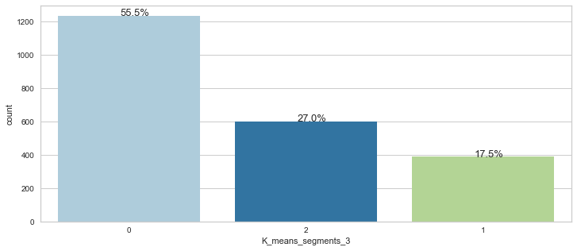

```python
perc_on_bar('K_means_segments_3')
```

**Let's visualize the clusters using PCA**

```python
# Function to visualize PCA data with clusters formed
def PCA_PLOT(X, Y, PCA, cluster):
    sns.scatterplot(x=X, y=1, data=PCA, hue=cluster)
```

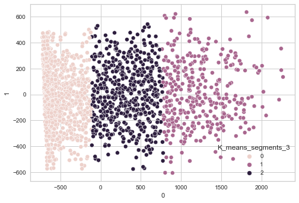

```python
PCA_PLOT(0, 1, data_pca, "K_means_segments_3")
```

**Observations and Insights:**

We can observe 3 clusters based on K-Means algorithm:

- Cluster 0: the lowest income and biggest cluster. Points are dense and close together
- Cluster 1: Points much more spread apart - the high value customers
- Cluster 2: middle income high frequency customers.

With these 3 clusters, we get high value and high loyalty/frequency customers vs low value. But the low value group is a large proportion of the dataset.

### **Cluster Profiling**

```python
# Taking the cluster-wise mean of all the variables.
# Hint: First groupby 'data' by 'K_means_segments_3' and then find mean
cluster_profile_KMeans_3 = data_model.groupby('K_means_segments_3').mean()
```

```python
# Highlighting the maximum average value among all the clusters for each of the variables

cluster_profile_KMeans_3.style.highlight_max(color="lightgreen", axis=0)
```

| K_means_segments_3 | Expenses | NumTotalPurchases | AmtPerPurchase | TotalCamp | Recency | Engaged_Days | NumStorePurchases | NumCatalogPurchases | NumWebPurchases | NumDealsPurchases | NumWebVisitsMonth | Wine | FishMeat | Dessert | Gold |
| --- | --- | --- | --- | --- | --- | --- | --- | --- | --- | --- | --- | --- | --- | --- | --- |
| 0 | 145.988673 | 9.441748 | 13.027471 | 0.199029 | 48.633495 | 514.457120 | 3.666667 | 0.770227 | 2.679612 | 2.325243 | 6.332524 | 69.312298 | 42.028317 | 13.848706 | 20.799353 |
| 1 | 1634.835476 | 21.632391 | 79.105690 | 1.303342 | 50.670951 | 592.712082 | 8.365039 | 6.092545 | 5.544987 | 1.629820 | 3.542416 | 835.221080 | 592.539846 | 129.526992 | 77.547558 |
| 2 | 884.638935 | 21.725458 | 42.510369 | 0.407654 | 49.096506 | 551.437604 | 8.600666 | 4.251248 | 6.106489 | 2.767055 | 4.420965 | 447.951747 | 279.960067 | 86.128120 | 70.599002 |

**Observations and Insights:**

- Upon deciding on K=3 clusters, each group now has a 'centroid' - the mean of each variable within that cluster
- Seeing the representative mean of each variable allows us to make assumptions about each cluster

**Let us create a boxplot for each of the variables**

```python
# Columns to use in boxplot
col_for_box = ['Age',
               'Kidhome',
               'Teenhome',
               'Family_Size',
               'Income',
               'Recency',
               'Engaged_Days',
               'NumDealsPurchases',
               'NumWebPurchases',
               'NumCatalogPurchases',
               'NumStorePurchases',
               'NumWebVisitsMonth',
               'NumTotalPurchases',
               'Expenses',
               'AmtPerPurchase',
               'TotalCamp',
               'Wine',
               'FishMeat',
               'Dessert',
               'Gold']
```

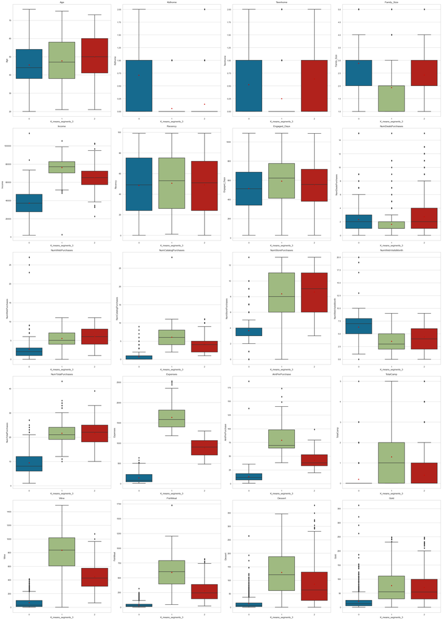

```python
# Creating boxplot for each of the variables
all_col = col_for_box

plt.figure(figsize = (30, 50))

for i, variable in enumerate(all_col):
    plt.subplot(6, 4, i + 1)

    sns.boxplot(y=data[variable], x=data['K_means_segments_3'],showmeans=True)

    plt.tight_layout()

    plt.title(variable)

plt.show()
```

### **Characteristics of each cluster:**

**Cluster 0: 1236 customers (56%)**

- Lowest income group
- Lowest spending group
- Lowest campaign conversion rate
- Lowest spend across all product categories

**Summary for cluster 0: Low Value - low spending and income, and low conversion**

**Summary for cluster 1: High Value - target group**

**Summary for cluster 2: High Potential - also a target group**

**Think About It:**

- Are the K-Means profiles with K=3 providing any deep insights into customer purchasing behavior or which channels they are using?
- What is the next step to get more meaningful insights?

We can see from the above profiles that K=3 segments the customers into High, Medium and Low-income customers.

We are getting some insight into the customer buying behaviour, but let's try to build K=4 (which has another elbow in the Elbow curve, even though the silhouette score is lower) and see if we can get better customer profiles.

```python
# Dropping labels we got from K=3 since we will be using PCA data for prediction
# Drop K_means_segments_3. Hint: Use axis=1 and inplace=True
data_pca.drop('K_means_segments_3', axis = 1, inplace = True)
data.drop('K_means_segments_3', axis = 1, inplace = True)
```

**Let's build K-Means using K=4**

```python
# Fit the K-Means algorithm using number of cluster as 4 and random_state=0 on data_pca

kmeans = KMeans(n_clusters = 4, random_state = 0)

# Fitting on the data_pca

kmeans.fit(data_pca)
```

```
KMeans(n_clusters=4, random_state=0)
```

```python
# Add K-Means cluster labels to data_pca
data_pca["K_means_segments_4"] = kmeans.labels_

# Add K-Means cluster labels to whole data
data["K_means_segments_4"] = kmeans.labels_

# Add K-Means cluster labels to data_model
data_model["K_means_segments_4"] = kmeans.labels_
```

```python
# Let's check the distribution

data_pca["K_means_segments_4"].value_counts()
```

```
0    1070
1     460
2     446
3     250
Name: K_means_segments_4, dtype: int64
```

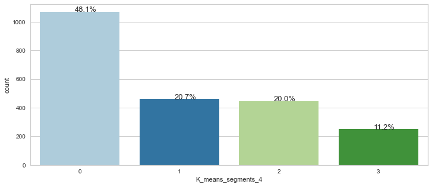

```python
perc_on_bar('K_means_segments_4')
```

**Let's visualize the clusters=4 using PCA**

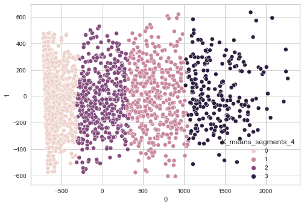

```python
# Hint: Use PCA_PLOT function created above

def PCA_PLOT(X, Y, PCA, cluster):
    sns.scatterplot(x=X, y=1, data=PCA, hue=cluster)

PCA_PLOT(0, 1, data_pca, "K_means_segments_4")
```

### **Cluster Profiling**

```python
# Take the cluster-wise mean of all the variables. Hint: First groupby 'data' by cluster labels column and then find mean

cluster_profile_KMeans_4 = data_model.groupby('K_means_segments_4').mean()
```

```python
# Highlight the maximum average value among all the clusters for each of the variables

cluster_profile_KMeans_4.style.highlight_max(color="lightgreen", axis=0)
```

| K_means_segments_4 | Expenses | NumTotalPurchases | AmtPerPurchase | TotalCamp | Recency | Engaged_Days | NumStorePurchases | NumCatalogPurchases | NumWebPurchases | NumDealsPurchases | NumWebVisitsMonth | Wine | FishMeat | Dessert | Gold | K_means_segments_3 |
| --- | --- | --- | --- | --- | --- | --- | --- | --- | --- | --- | --- | --- | --- | --- | --- | --- |
| 0 | 102.511215 | 8.197196 | 11.202856 | 0.174766 | 49.041121 | 504.064486 | 3.299065 | 0.564486 | 2.215888 | 2.117757 | 6.404673 | 45.299065 | 31.239252 | 10.635514 | 15.337383 | 0.000000 |
| 1 | 1146.989130 | 21.956522 | 54.970107 | 0.597826 | 49.432609 | 572.102174 | 8.765217 | 5.269565 | 5.741304 | 2.180435 | 3.856522 | 575.630435 | 384.784783 | 108.306522 | 78.267391 | 1.697826 |
| 2 | 590.778027 | 19.932735 | 29.921289 | 0.349776 | 47.477578 | 554.762332 | 7.441704 | 2.856502 | 6.177130 | 3.457399 | 5.334081 | 313.901345 | 161.630045 | 54.912556 | 60.334081 | 1.255605 |
| 3 | 1789.088000 | 21.524000 | 87.218399 | 1.520000 | 51.764000 | 591.632000 | 8.296000 | 6.300000 | 5.488000 | 1.440000 | 3.424000 | 906.120000 | 672.748000 | 134.296000 | 75.924000 | 1.000000 |

**Let's plot the boxplot**

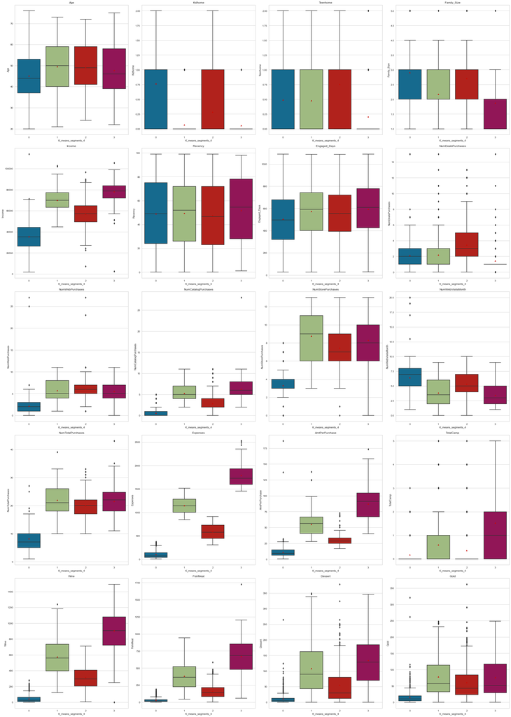

```python
# Create boxplot for each of the variables
all_col = col_for_box

plt.figure(figsize = (30, 50))

for i, variable in enumerate(all_col):
    plt.subplot(6, 4, i + 1)

    sns.boxplot(y=data[variable], x=data['K_means_segments_4'],showmeans=True)

    plt.tight_layout()

    plt.title(variable)

plt.show()
```

Using 4 clusters, each cluster is more evenly divided. Here we can further separate between big buyer and frequent buyers with discount sensitive buyers.

**Cluster 0: 1070 customers (48%)**

- The largest cluster
- Low income
- Low buyer group

**Summary for cluster 0: Non buyers**

**Cluster 1: 460 customers (21%)**

- Second highest income group
- Frequent buyer group
- Highest store purchase
- Responsive to deals and discounts

**Summary for cluster 1: Frequent buyer in-store buyers**

**Cluster 2: 446 customers (20%)**

- Low conversion rates
- Discount sensitive
- Online buyers

**Summary for cluster 2: Discount sensitive middle income group through online or in-store purchases**

**Cluster 3: 250 customers (11%)**

- Highest spending & AmountPerPurchase group
- High conversion rates - most likely to respond to marketing campaigns
- Highest income
- Wine buyers
- Highest catalog buyers
- The smallest cluster

**Summary for cluster 3: High Conversion, High Income Biggest Buyer Group through Catalog purchase**

```python
# Dropping labels we got from K-Means since we will be using PCA data for prediction
# Hint: Use axis=1 and inplace=True
data_pca.drop('K_means_segments_4', axis = 1, inplace = True)
data.drop('K_means_segments_4', axis = 1, inplace = True)
```

From the above profiles, K=4 provides more interesting insights about customer's purchasing behavior and preferred channels for purchasing products, which was not evident in K=3. So, **we can choose K=4**

## **K-Medoids**

The main difference between K-Means and K-Medoids is that K-Means will form clusters based on the distance of observations to each centroid, while K-Medoid forms clusters based on the distance to medoids.

K-Means is sensitive to outliers, but K-Medoids has mitigated that sensitivity by not relying on centroids

```python
distortions = []                                                  # Create an empty list

K = range(2, 10)                                                  # Setting the K range from 2 to 10

for k in K:
    kmedoidModel = KMedoids(n_clusters=k, random_state=4)         # Initialize K-Means

    kmedoidModel.fit(data_pca)                                    # Fit K-Means on the data

    distortions.append(kmedoidModel.inertia_)
```

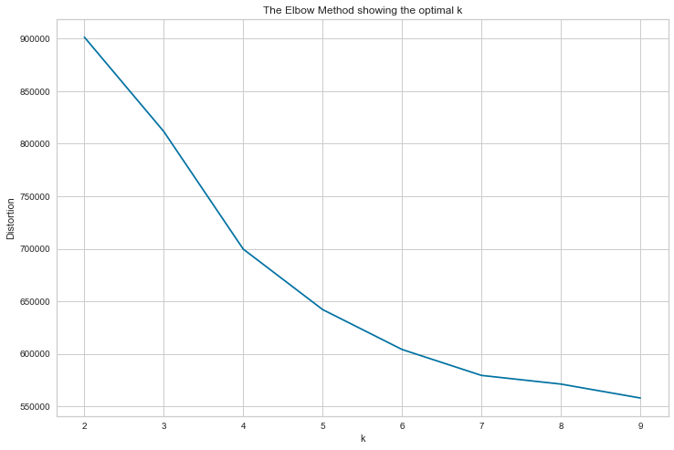

```python
# Plotting the elbow plot
plt.figure(figsize=(12, 8))                                            # Setting the plot size

plt.plot(K, distortions, "bx-")                                        # Plotting the K on X-axis and distortions on y-axis

plt.xlabel("k")                                                        # Title of x-axis

plt.ylabel("Distortion")                                               # Title of y-axis

plt.title("The Elbow Method showing the optimal k")                    # Title of the plot
plt.show()
```

```python
#Creating empty list
sil_score = []

#Creating a range from 3 to 7
cluster_list = range(3, 7)

for n_clusters in cluster_list:

    # Initialize K-Medoids with number of clusters equal to n_clusters and random_state=1
    kmedo = KMedoids(n_clusters, random_state = 1).fit(data_pca)

    # Fit and predict on the pca data
    preds = kmedo.predict(data_pca)

    # Calculate silhouette score - Hint: Use silhouette_score() function
    score = silhouette_score(data_pca, preds)

    # Append silhouette score to empty list created above
    sil_score.append(score)

    # Print the silhouette score
    print( "For n_clusters = {}, the silhouette score is {})".format(n_clusters, score))
```

```
For n_clusters = 3, the silhouette score is 0.33627648121125675)
For n_clusters = 4, the silhouette score is 0.340992436500432)
For n_clusters = 5, the silhouette score is 0.3310352623218519)
For n_clusters = 6, the silhouette score is 0.32893798896728427)
```

**We will use 4 clusters for K-Medoids, since it has the highest silhouette score of 0.34099**

```python
# Initializing K-Medoids with number of clusters as 4 and random_state=1
kmedo = KMedoids(n_clusters = 4, random_state = 1).fit(data_pca)

# Fit and predict K-Medoids using data_pca
preds = kmedo.fit_predict(data_pca)

# Calculate the silhouette score
score = silhouette_score(data_pca, preds)

print(score)                   # Print the score
```

```
0.340992436500432
```

```python
# Predicting on data_pca and ddding K-Medoids cluster labels to the whole data
data["K_medoid_segments_4"] = kmedo.labels_

# Predicting on data_pca and ddding K-Medoids cluster labels to data_model
data_model["K_medoid_segments_4"] = kmedo.labels_

# Predicting on data_pca and ddding K-Medoids cluster labels to data_pca
data_pca["K_medoid_segments_4"] = kmedo.labels_
```

```python
# Let's check the distribution
data_pca["K_medoid_segments_4"].value_counts()
```

```
3    650
1    571
2    512
0    493
Name: K_medoid_segments_4, dtype: int64
```

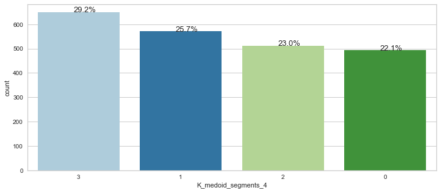

```python
perc_on_bar('K_medoid_segments_4')
```

**Let's visualize the clusters using PCA**

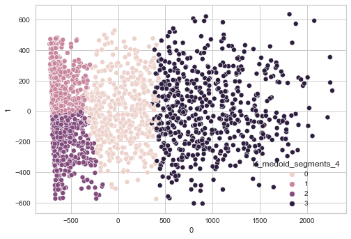

```python
# Hint: Use PCA_PLOT function created above

def PCA_PLOT(X, Y, PCA, cluster):
    sns.scatterplot(x=X, y=1, data=PCA, hue=cluster)

PCA_PLOT(0, 1, data_pca, "K_medoid_segments_4")
```

### **Cluster Profiling**

```python
# Take the cluster-wise mean of all the variables. Hint: First group 'data' by cluster labels column and then find mean

cluster_profile_KMedo_4 = data_model.groupby('K_medoid_segments_4').mean()
```

```python
# Highlight the maximum average value among all the clusters for each of the variables

cluster_profile_KMedo_4.style.highlight_max(color="lightgreen", axis=0)
```

| K_medoid_segments_4 | Expenses | NumTotalPurchases | AmtPerPurchase | TotalCamp | Recency | Engaged_Days | NumStorePurchases | NumCatalogPurchases | NumWebPurchases | NumDealsPurchases | NumWebVisitsMonth | Wine | FishMeat | Dessert | Gold | K_means_segments_3 | K_means_segments_4 |
| --- | --- | --- | --- | --- | --- | --- | --- | --- | --- | --- | --- | --- | --- | --- | --- | --- | --- |
| 0 | 634.010142 | 20.170385 | 32.168298 | 0.359026 | 48.286004 | 533.521298 | 7.634888 | 3.113590 | 6.148073 | 3.273834 | 5.164300 | 340.413793 | 174.225152 | 58.154158 | 61.217039 | 1.379310 | 1.837728 |
| 1 | 90.679510 | 7.830123 | 10.232735 | 0.150613 | 48.607706 | 327.847636 | 3.309982 | 0.516637 | 2.056042 | 1.947461 | 5.889667 | 42.523643 | 26.728546 | 9.259194 | 12.168126 | 0.000000 | 0.000000 |
| 2 | 123.855469 | 8.880859 | 12.299654 | 0.214844 | 49.421875 | 720.023438 | 3.349609 | 0.662109 | 2.484375 | 2.384766 | 6.984375 | 51.304688 | 39.142578 | 13.138672 | 20.269531 | 0.000000 | 0.089844 |
| 3 | 1415.849231 | 21.815385 | 68.343866 | 0.961538 | 49.946154 | 583.029231 | 8.593846 | 5.704615 | 5.633846 | 1.883077 | 3.656923 | 709.872308 | 506.930769 | 120.895385 | 78.150769 | 1.401538 | 1.769231 |

**Let's plot the boxplot**

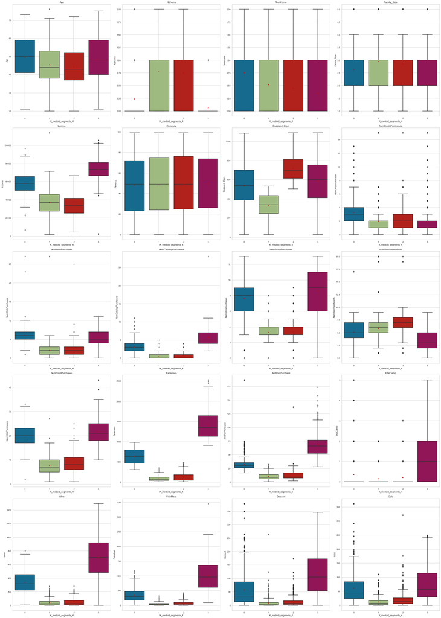

```python
# Create boxplot for each of the variables

all_col = col_for_box

plt.figure(figsize = (30, 50))

for i, variable in enumerate(all_col):
    plt.subplot(6, 4, i + 1)

    sns.boxplot(y=data[variable], x=data['K_medoid_segments_4'],showmeans=True)

    plt.tight_layout()

    plt.title(variable)

plt.show()
```

### **Characteristics of each cluster**

**Cluster 0: 493 customers (22%)**

- High potential and deal sensitive customers
- Buyers across all channels, esp online
- Oldest age-group customers

**Summary for cluster 0: High Potential - High frequency buyers**

**Cluster 1: 571 customers (26%)**

- Low spending customers
- Newest customers

**Summary for cluster 1: Low Value Customers**

**Cluster 2: 512 customers (23%)**

**Summary for cluster 2: High Loyalty Customers - who have been engaged with the store the longest**

**Cluster 3: 650 customers (29%)**

- High income, high frequency big buyers
- Prefer in-store and catalog purchases
- Highest purchase across all product categories

**Summary for cluster 3: High Value - Big buyer high frequency customers**

```python
# Dropping labels we got from K-Medoids since we will be using PCA data for prediction
# Hint: Use axis=1 and inplace=True
data_pca.drop('K_medoid_segments_4', axis = 1, inplace = True)
data.drop('K_medoid_segments_4', axis = 1, inplace = True)
```

**Observations and Insights:**

- One of the problems with the K-Means clustering is that the final centroids does not necessarily have to be an actual datapoint but the mean of the points in the cluster.
- The idea of K-Medoids clustering is to make the final centroids as actual data-points. This result to make the centroids interpretable.
- What this means for customer segmentation is that we can use an actual customer within each cluster as a customer archetype.
- Here we have customers segmented by:
  - **High Potential**
  - **Low Value**
  - **High Loyalty**
  - **High Value**

## **Hierarchical Clustering**

Let's find the Cophenetic correlation for different distances with different linkage methods.

### **What is a Cophenetic correlation?**

The cophenetic correlation coefficient is a correlation coefficient between the cophenetic distances (Dendrogramic distance) obtained from the tree, and the original distances used to construct the tree. It is a measure of how faithfully a dendrogram preserves the pairwise distances between the original unmodeled data points.

The cophenetic distance between two observations is represented in a dendrogram by the height of the link at which those two observations are first joined. That height is the distance between the two subclusters that are merged by that link.

Cophenetic correlation is the way to compare two or more dendrograms.

**Let's calculate Cophenetic correlation for each of the distance metrics with each of the linkage methods**

```python
# list of distance metrics
distance_metrics = ["euclidean", "chebyshev", "mahalanobis", "cityblock"]

# list of linkage methods
linkage_methods = ["single", "complete", "average"]

high_cophenet_corr = 0                                                 # Creating a variable by assigning 0 to it
high_dm_lm = [0, 0]                                                    # Creating a list by assigning 0's to it

for dm in distance_metrics:
    for lm in linkage_methods:
        Z = linkage(data_pca, metric=dm, method=lm)                    # Applying different linkages with different distance on data_pca
        c, coph_dists = cophenet(Z, pdist(data_pca))                   # Calculating cophenetic correlation
        print(
            "Cophenetic correlation for {} distance and {} linkage is {}.".format(
                dm.capitalize(), lm, c
            )
        )
        if high_cophenet_corr < c:                                     # Checking if cophenetic correlation is higher than previous score
            high_cophenet_corr = c                                     # Appending to high_cophenet_corr list if it is higher
            high_dm_lm[0] = dm                                         # Appending its corresponding distance
            high_dm_lm[1] = lm                                         # Appending its corresponding method or linkage
```

```
Cophenetic correlation for Euclidean distance and single linkage is 0.721951891715258.
Cophenetic correlation for Euclidean distance and complete linkage is 0.778293934454146.
Cophenetic correlation for Euclidean distance and average linkage is 0.8155891712601889.
Cophenetic correlation for Chebyshev distance and single linkage is 0.6946847827519552.
Cophenetic correlation for Chebyshev distance and complete linkage is 0.8096092895411763.
Cophenetic correlation for Chebyshev distance and average linkage is 0.7842806367877544.
Cophenetic correlation for Mahalanobis distance and single linkage is 0.3758211123443316.
Cophenetic correlation for Mahalanobis distance and complete linkage is 0.35916458211149654.
Cophenetic correlation for Mahalanobis distance and average linkage is 0.37212562165658486.
Cophenetic correlation for Cityblock distance and single linkage is 0.7237224448274585.
Cophenetic correlation for Cityblock distance and complete linkage is 0.7977006862651915.
Cophenetic correlation for Cityblock distance and average linkage is 0.7936690184491257.
```

```python
# Printing the combination of distance metric and linkage method with the highest cophenetic correlation
print(
    "Highest cophenetic correlation is {}, which is obtained with {} distance and {} linkage.".format(
        high_cophenet_corr, high_dm_lm[0].capitalize(), high_dm_lm[1]
    )
)
```

```
Highest cophenetic correlation is 0.8155891712601889, which is obtained with Euclidean distance and average linkage.
```

**Let's have a look at the dendrograms for different linkages with `Cityblock distance`**

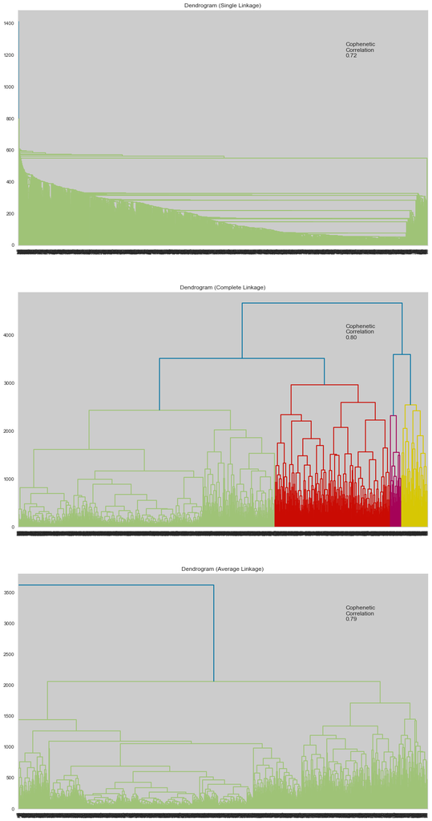

```python
# List of linkage methods
linkage_methods = ["single", "complete", "average"]

# Lists to save results of cophenetic correlation calculation
compare_cols = ["Linkage", "Cophenetic Coefficient"]

# To create a subplot image
fig, axs = plt.subplots(len(linkage_methods), 1, figsize=(15, 30))            # Setting the plot size

# We will enumerate through the list of linkage methods above
# For each linkage method, we will plot the dendrogram and calculate the cophenetic correlation
for i, method in enumerate(linkage_methods):
    Z = linkage(data_pca, metric="Cityblock", method=method)                  # Measures the distances between two clusters

    dendrogram(Z, ax=axs[i])
    axs[i].set_title(f"Dendrogram ({method.capitalize()} Linkage)")           # Title of dendrogram

    coph_corr, coph_dist = cophenet(Z, pdist(data_pca))                       # Finding cophenetic correlation for different linkages with city block distance
    axs[i].annotate(
        f"Cophenetic\nCorrelation\n{coph_corr:0.2f}",
        (0.80, 0.80),
        xycoords="axes fraction",
    )
```

**Observations and Insights:**

The plots above show how the choice of linkage affects the cluster formation. Visually looking into every dendrogram to determine which clustering linkage works best is challenging. So, with the concept of Cophenetic Coefficient. We look for the highest number.

Above, the **highest Cophenetic Coefficient (with Euclidean distance and Average linkage) is 0.82**.

There are no statistical techniques to decide the number of clusters in hierarchical clustering, unlike a K-Means algorithm that uses an elbow plot to determine the number of clusters. However, one common approach is to analyze the dendrogram and look for groups that combine at a higher dendrogram distance.

The biggest drop/distance where we cut the dendogram distance just above 3000. We can see **4 clusters**

**Think about it:**

- Can we clearly decide the number of clusters based on where to cut the dendrogram horizontally?
- What is the next step in obtaining number of clusters based on the dendrogram?

**Let's have a look at the dendrograms for different linkages with `Chebyshev distance`**

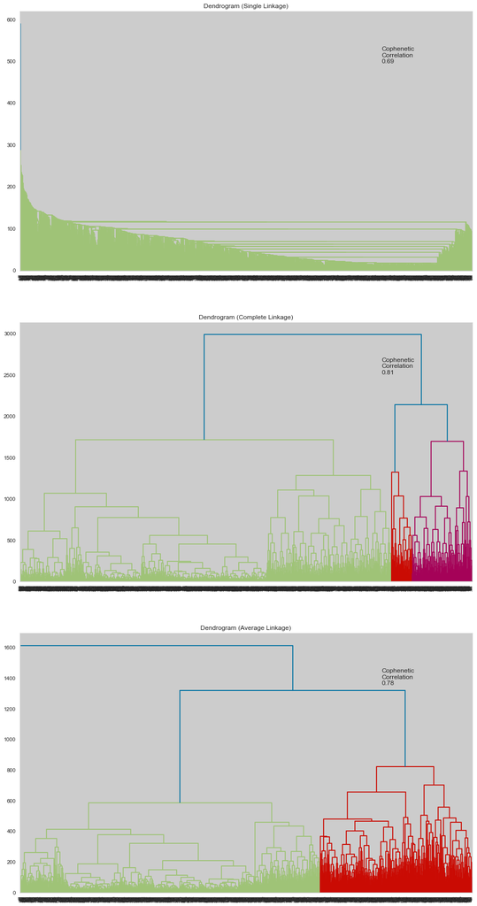

```python
# Plot the dendrogram for Chebyshev distance with linkages single, complete and average.
# Hint: Use Chebyshev distance as the metric in the linkage() function

# List of linkage methods
linkage_methods = ["single", "complete", "average"]

# Lists to save results of cophenetic correlation calculation
compare_cols = ["Linkage", "Cophenetic Coefficient"]

# To create a subplot image
fig, axs = plt.subplots(len(linkage_methods), 1, figsize=(15, 30))            # Setting the plot size

# We will enumerate through the list of linkage methods above
# For each linkage method, we will plot the dendrogram and calculate the cophenetic correlation
for i, method in enumerate(linkage_methods):
    Z = linkage(data_pca, metric="chebyshev", method=method)                  # Measures the distances between two clusters

    dendrogram(Z, ax=axs[i])
    axs[i].set_title(f"Dendrogram ({method.capitalize()} Linkage)")           # Title of dendrogram

    coph_corr, coph_dist = cophenet(Z, pdist(data_pca))                       # Finding cophenetic correlation for different linkages with city block distance
    axs[i].annotate(
        f"Cophenetic\nCorrelation\n{coph_corr:0.2f}",
        (0.80, 0.80),
        xycoords="axes fraction",
    )
```

**Observations and Insights:**

Chebyshev distance with Complete Linkage shows the highest cophenetic correlation of 0.81.

We observe **5 clusters** from this plot

**Let's have a look at the dendrograms for different linkages with Mahalanobis distance**

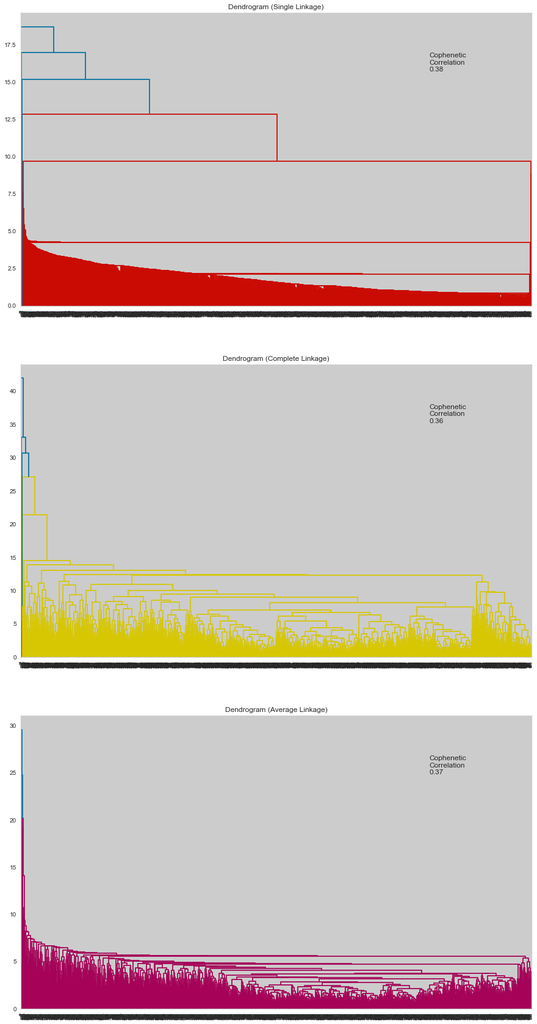

```python
# Plot the dendrogram for Mahalanobis distance with linkages single, complete and average.
# Hint: Use Mahalanobis distance as the metric in the linkage() function

# List of linkage methods
linkage_methods = ["single", "complete", "average"]

# Lists to save results of cophenetic correlation calculation
compare_cols = ["Linkage", "Cophenetic Coefficient"]

# To create a subplot image
fig, axs = plt.subplots(len(linkage_methods), 1, figsize=(15, 30))            # Setting the plot size

# We will enumerate through the list of linkage methods above
# For each linkage method, we will plot the dendrogram and calculate the cophenetic correlation
for i, method in enumerate(linkage_methods):
    Z = linkage(data_pca, metric="mahalanobis", method=method)                  # Measures the distances between two clusters

    dendrogram(Z, ax=axs[i])
    axs[i].set_title(f"Dendrogram ({method.capitalize()} Linkage)")           # Title of dendrogram

    coph_corr, coph_dist = cophenet(Z, pdist(data_pca))                       # Finding cophenetic correlation for different linkages with city block distance
    axs[i].annotate(
        f"Cophenetic\nCorrelation\n{coph_corr:0.2f}",
        (0.80, 0.80),
        xycoords="axes fraction",
    )
```

**Observations and Insights:**

Mahalanobis distance gives us much lower cophenetic coefficient (0.38) than Cityblock and Chebyshev. And no clear clusters from the dendogram

**Let's have a look at the dendrograms for different linkages with Euclidean distance**

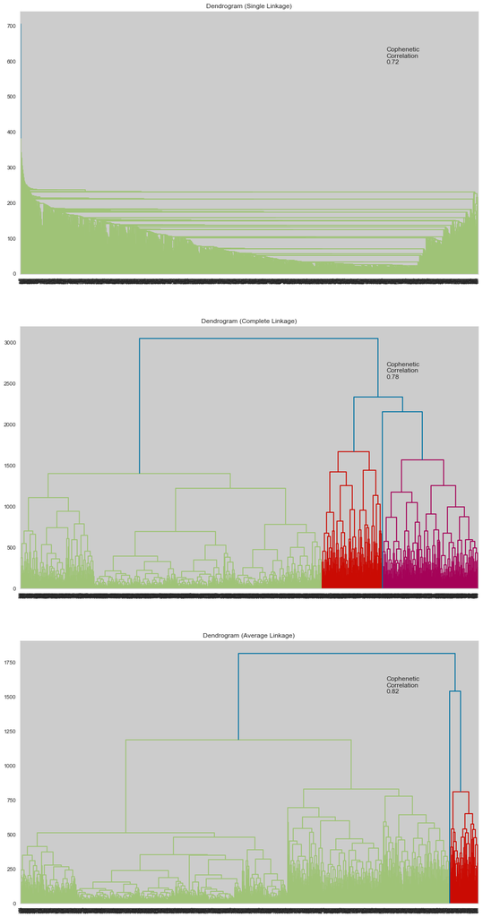

```python
# Plot the dendrogram for Euclidean distance with linkages single, complete, average and ward.
# Hint: Use Euclidean distance as the metric in the linkage() function

# List of linkage methods
linkage_methods = ["single", "complete", "average"]

# Lists to save results of cophenetic correlation calculation
compare_cols = ["Linkage", "Cophenetic Coefficient"]

# To create a subplot image
fig, axs = plt.subplots(len(linkage_methods), 1, figsize=(15, 30))            # Setting the plot size

# We will enumerate through the list of linkage methods above
# For each linkage method, we will plot the dendrogram and calculate the cophenetic correlation
for i, method in enumerate(linkage_methods):
    Z = linkage(data_pca, metric="euclidean", method=method)                  # Measures the distances between two clusters

    dendrogram(Z, ax=axs[i])
    axs[i].set_title(f"Dendrogram ({method.capitalize()} Linkage)")           # Title of dendrogram

    coph_corr, coph_dist = cophenet(Z, pdist(data_pca))                       # Finding cophenetic correlation for different linkages with city block distance
    axs[i].annotate(
        f"Cophenetic\nCorrelation\n{coph_corr:0.2f}",
        (0.80, 0.80),
        xycoords="axes fraction",
    )
```

**Think about it:**

- Are there any distinct clusters in any of the dendrograms?

**Observations and Insights:**

As mentioned above, Euclidean distance with Average linkage gives us the highest Cophenetic Correlation of 0.82 out of all the hyperparameters for Hierarchical Clustering. We see **6 distinct clusters.**

```python
# Initialize Agglomerative Clustering with affinity (distance) as Euclidean, linkage as 'ward' with clusters=6
HCmodel = AgglomerativeClustering(n_clusters=6, affinity='euclidean', linkage='ward',)

# Fit on data_pca
HCmodel.fit(data_pca)
```

```
AgglomerativeClustering(n_clusters=6)
```

```python
# Fit and predict K-Medoids using data_pca
preds = HCmodel.fit_predict(data_pca)

# Calculate the silhouette score
score = silhouette_score(data_pca, preds)

print(score)                   # Print the score
```

```
0.29812549067396915
```

```python
# Add Agglomerative Clustering cluster labels to data_pca
data_pca["AgglomerativeClustering_6"] = HCmodel.labels_

# Add Agglomerative Clustering cluster labels to the whole data
data["AgglomerativeClustering_6"] = HCmodel.labels_

# Add Agglomerative Clustering cluster labels to data_model
data_model["AgglomerativeClustering_6"] = HCmodel.labels_
```

```python
# Let's check the distribution
data_model["AgglomerativeClustering_6"].value_counts()
```

```
0    552
2    518
5    441
1    344
4    225
3    146
Name: AgglomerativeClustering_6, dtype: int64
```

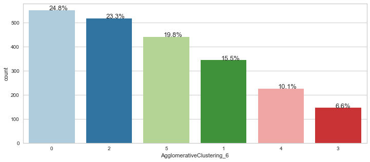

```python
perc_on_bar('AgglomerativeClustering_6')
```

**Let's visualize the clusters using PCA.**

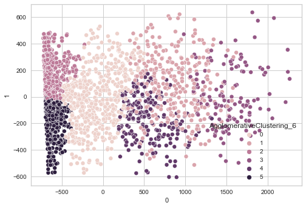

```python
# Hint: Use PCA_PLOT function created above
def PCA_PLOT(X, Y, PCA, cluster):
    sns.scatterplot(x=X, y=1, data=PCA, hue=cluster)

PCA_PLOT(0, 1, data_pca, "AgglomerativeClustering_6")
```

### **Cluster Profiling**

```python
# Take the cluster-wise mean of all the variables. Hint: First group 'data' by cluster labels column and then find mean

cluster_profile_HCmodel = data_model.groupby('AgglomerativeClustering_6').mean()
```

```python
# Highlight the maximum average value among all the clusters for each of the variables

cluster_profile_HCmodel.style.highlight_max(color="lightgreen", axis=0)
```

| AgglomerativeClustering_6 | Expenses | NumTotalPurchases | AmtPerPurchase | TotalCamp | Recency | Engaged_Days | NumStorePurchases | NumCatalogPurchases | NumWebPurchases | NumDealsPurchases | NumWebVisitsMonth | Wine | FishMeat | Dessert | Gold | K_means_segments_3 | K_means_segments_4 | K_medoid_segments_4 |
| --- | --- | --- | --- | --- | --- | --- | --- | --- | --- | --- | --- | --- | --- | --- | --- | --- | --- | --- |
| 0 | 532.306159 | 18.565217 | 28.834863 | 0.331522 | 47.630435 | 545.835145 | 6.882246 | 2.606884 | 5.706522 | 3.369565 | 5.409420 | 278.807971 | 148.487319 | 49.847826 | 55.163043 | 0.996377 | 1.543478 | 0.432971 |
| 1 | 1345.959302 | 21.081395 | 66.551845 | 0.697674 | 49.555233 | 522.360465 | 8.392442 | 5.985465 | 5.252907 | 1.450581 | 2.822674 | 532.404070 | 588.976744 | 145.069767 | 79.508721 | 1.421512 | 1.587209 | 2.938953 |
| 2 | 81.791506 | 7.557915 | 9.701395 | 0.156371 | 47.542471 | 312.320463 | 3.231660 | 0.455598 | 1.972973 | 1.897683 | 5.874517 | 36.536680 | 25.332046 | 8.913127 | 11.009653 | 0.000000 | 0.007722 | 1.003861 |
| 3 | 1888.383562 | 21.253425 | 92.722070 | 1.863014 | 53.650685 | 587.527397 | 8.171233 | 6.109589 | 5.527397 | 1.445205 | 3.678082 | 1055.595890 | 636.589041 | 115.904110 | 80.294521 | 1.000000 | 2.986301 | 3.000000 |
| 4 | 1050.924444 | 23.720000 | 46.370621 | 0.640000 | 49.368889 | 708.955556 | 9.257778 | 4.622222 | 6.648889 | 3.191111 | 5.431111 | 698.724444 | 211.862222 | 69.164444 | 71.173333 | 1.804444 | 1.173333 | 2.120000 |
| 5 | 83.192744 | 7.453515 | 10.467087 | 0.176871 | 50.843537 | 702.446712 | 2.990930 | 0.478458 | 1.943311 | 2.040816 | 7.036281 | 28.310658 | 28.106576 | 10.759637 | 16.015873 | 0.000000 | 0.000000 | 1.950113 |

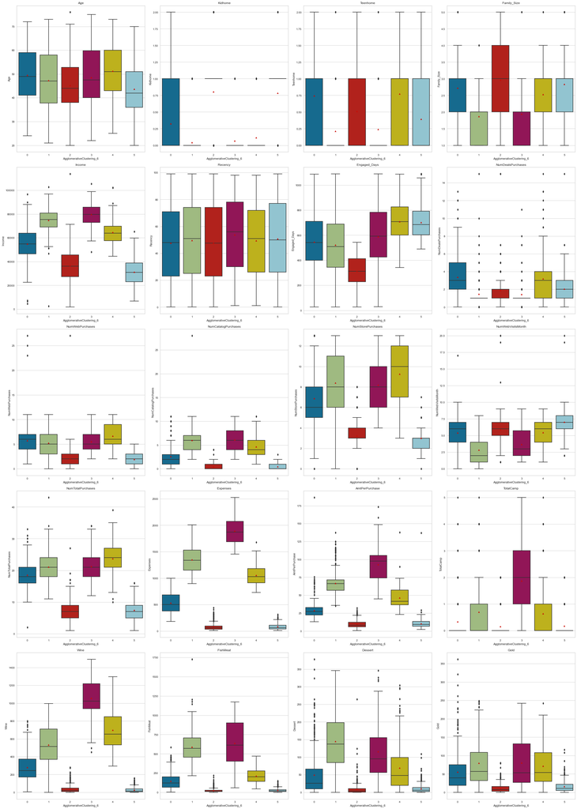

```python
# Create boxplot for each of the variables

all_col = col_for_box

plt.figure(figsize = (30, 50))

for i, variable in enumerate(all_col):
    plt.subplot(6, 4, i + 1)

    sns.boxplot(y=data[variable], x=data['AgglomerativeClustering_6'],showmeans=True)

    plt.tight_layout()

    plt.title(variable)

plt.show()
```

### **Characteristics of each cluster**

**Cluster 0: 552 customers (25%)**

- Above average frequency buyers
- Discount-responsive shoppers

**Summary for cluster 0: High frequency discount-responsive**

- Biggest buyers of fruit and sweets
- 2nd highest buyer group
- This group separates the wine buyers from the rest of the product categories

**Summary for cluster 1: High frequency buyers**

- Low spenders
- Newest customers

**Sumamary for cluser 2: Low value customers**

- Highest income, expense and campaign conversion group
- Biggest wine buyers
- High frequency buyers

**Summary for Cluster 3: High Value - Big buyer group**

**Cluster 4: 225 customers (10%)

**Summary for Cluster 4: High Loyalty customers**

```python
# Dropping labels we got from Agglomerative Clustering since we will be using PCA data for prediction
# Hint: Use axis=1 and inplace=True
data_pca.drop('AgglomerativeClustering_6', axis = 1, inplace = True)
data.drop('AgglomerativeClustering_6', axis = 1, inplace = True)
```

## **DBSCAN**

DBSCAN is a very powerful algorithm for finding **high-density clusters**, but the problem is determining the best set of hyperparameters to use with it. It includes two hyperparameters, `eps`, and `min samples`.

Since it is an unsupervised algorithm, you have no control over it, unlike a supervised learning algorithm, which allows you to test your algorithm on a validation set. The approach we can follow is basically trying out a bunch of different combinations of values and finding the silhouette score for each of them.

```python
from sklearn.neighbors import NearestNeighbors
```

**To find the optimal eps value**

```python
neighbors = NearestNeighbors(n_neighbors=10)
neighbors_fit = neighbors.fit(data_pca)
distances, indices = neighbors_fit.kneighbors(data_pca)
```

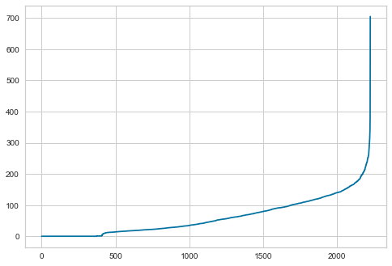

```python
distances = np.sort(distances, axis=0)
distances = distances[:,1]
plt.plot(distances)
```

The optimum value of epsilon is at **the point of maximum curvature in the K-Distance Graph, which is 200** in this case.

**Now, let's apply DBSCAN using the hyperparameter values we have received above.**

```python
# Applying DBSCAN with eps as 200 and min sample as 20

dbs = DBSCAN(eps=200, min_samples=20)
```

```python
# Fit and predict K-Medoids using data_pca
preds = dbs.fit_predict(data_pca)

# Calculate the silhouette score
score = silhouette_score(data_pca, preds)

print(score)                   # Print the score
```

```
0.3579692327245481
```

```python
data["DBSLabels"] = dbs.fit_predict(data_pca)                   # fit_predict on data_pca and adding DBSCAN cluster labels to the whole data

data_model["DBSLabels"] = dbs.fit_predict(data_pca)             # fit_predict on data_pca and adding DBSCAN cluster labels to data_model

data_pca["DBSLabels"] = dbs.fit_predict(data_pca)               # fit_predict on data_pca and adding DBSCAN cluster labels to pca_data
```

```python
# Let's check the distribution
data_model["DBSLabels"].value_counts()
```

```
 0    1696
-1     498
 1      32
Name: DBSLabels, dtype: int64
```

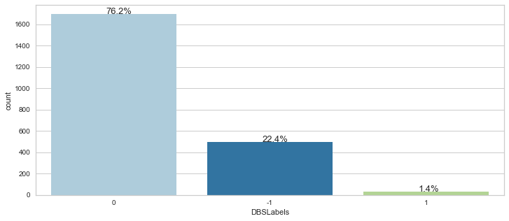

```python
perc_on_bar('DBSLabels')
```

**Let's visualize the clusters using PCA.**

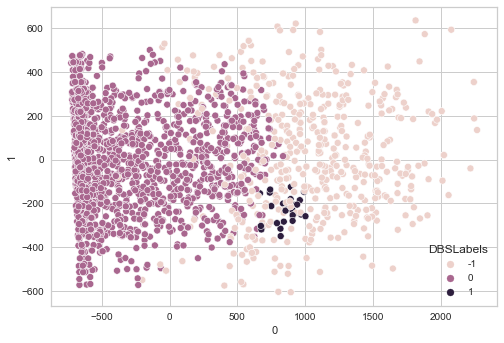

```python
# Hint: Use PCA_PLOT function created above
def PCA_PLOT(X, Y, PCA, cluster):
    sns.scatterplot(x=X, y=1, data=PCA, hue=cluster)

PCA_PLOT(0, 1, data_pca, "DBSLabels")
```

### *Cluster Profiling*

```python
# Take the cluster-wise mean of all the variables. Hint: First group 'data' by cluster labels column and then find mean

cluster_profile_dbs = data_model.groupby('DBSLabels').mean()
```

```python
# Highlight the maximum average value among all the clusters for each of the variables

cluster_profile_dbs.style.highlight_max(color="lightgreen", axis=0)
```

| DBSLabels | Expenses | NumTotalPurchases | AmtPerPurchase | TotalCamp | Recency | Engaged_Days | NumStorePurchases | NumCatalogPurchases | NumWebPurchases | NumDealsPurchases | NumWebVisitsMonth | Wine | FishMeat | Dessert | Gold | K_means_segments_3 | K_means_segments_4 | K_medoid_segments_4 | AgglomerativeClustering_6 |
| --- | --- | --- | --- | --- | --- | --- | --- | --- | --- | --- | --- | --- | --- | --- | --- | --- | --- | --- | --- |
| -1 | 1485.355422 | 21.624498 | 72.176161 | 1.114458 | 50.329317 | 581.931727 | 8.437751 | 5.901606 | 5.570281 | 1.714859 | 3.520080 | 710.933735 | 556.817269 | 132.971888 | 84.632530 | 1.257028 | 2.064257 | 2.773092 | 1.839357 |
| 0 | 335.041863 | 12.760613 | 20.419928 | 0.237028 | 48.853184 | 521.487618 | 4.997052 | 1.648585 | 3.625000 | 2.489976 | 5.852005 | 173.272406 | 99.148585 | 30.544222 | 32.076651 | 0.545401 | 0.614387 | 1.219340 | 2.287146 |
| 1 | 1253.843750 | 22.843750 | 57.714797 | 1.281250 | 44.062500 | 737.593750 | 8.687500 | 4.437500 | 6.781250 | 2.937500 | 5.750000 | 996.093750 | 164.062500 | 38.843750 | 54.843750 | 1.250000 | 1.000000 | 3.000000 | 4.000000 |

**Observations and Insights:**

Testing different hyperparameters of eps and min_samples gives me too many very small clusters to make it useful.

We can conclude that **DBSCAN is not useful for this spherical dataset**

```python
# Dropping labels we got from DBSCAN since we will be using PCA data for prediction
# Hint: Use axis=1 and inplace=True
data_pca.drop('DBSLabels', axis = 1, inplace = True)
data.drop('DBSLabels', axis = 1, inplace = True)
```

## **Gaussian Mixture Model**

**Let's find the silhouette score for K=4 in Gaussian Mixture**

```python
#Creating empty list
sil_score = []

#Creating a range from 3 to 7
cluster_list = range(3, 7)

for n_clusters in cluster_list:

    # Initialize K-Medoids with number of clusters equal to n_clusters and random_state=1
    gmm = GaussianMixture (n_clusters, random_state = 1).fit(data_pca)

    # Fit and predict on the pca data
    labels = gmm.predict(data_pca)

    # Calculate silhouette score - Hint: Use silhouette_score() function
    score = silhouette_score(data_pca, labels)

    # Append silhouette score to empty list created above
    sil_score.append(score)

    # Print the silhouette score
    print( "For n_clusters = {}, the silhouette score is {})".format(n_clusters, score))
```

```
For n_clusters = 3, the silhouette score is 0.2890359862373438)
For n_clusters = 4, the silhouette score is 0.2547331011001941)
For n_clusters = 5, the silhouette score is 0.1145397272275401)
For n_clusters = 6, the silhouette score is 0.11733804177553349)
```

**Observations and Insights:**

GMM gives us the **lowest silhouette score** amongst all the algorithms. This could be because data is based on their probability of belonging to the each cluster, hence the overlap

k=3 gives us the highest silhouette score of 0.289, so we will initialize GMM on 3 clusters

```python
# Initialize Gaussian Mixture Model with number of clusters as 4 and random_state=1
gmm = GaussianMixture(n_components = 3, random_state = 1)

# Fit and predict Gaussian Mixture Model using data_pca
labels = gmm.fit_predict(data_pca)
```

```python
# Predicting on data_pca and add Gaussian Mixture Model cluster labels to the whole data
data['GMMLabels'] = gmm.predict(data_pca)

# Predicting on data_pca and add Gaussian Mixture Model cluster labels to data_model
data_model['GMMLabels'] = gmm.predict(data_pca)

# Predicting on data_pca and add Gaussian Mixture Model cluster labels to data_pca
data_pca['GMMLabels'] = gmm.predict(data_pca)
```

```python
# Let's check the distribution
data_model['GMMLabels'].value_counts()
```

```
1    797
2    723
0    706
Name: GMMLabels, dtype: int64
```

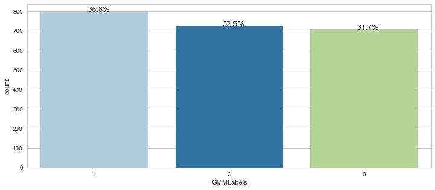

```python
perc_on_bar('GMMLabels')
```

**Let's visualize the clusters using PCA.**

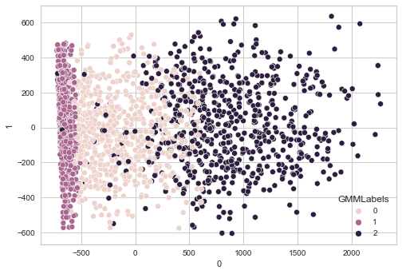

```python
# Hint: Use PCA_PLOT function created above
def PCA_PLOT(X, Y, PCA, cluster):
    sns.scatterplot(x=X, y=1, data=PCA, hue=cluster)

PCA_PLOT(0, 1, data_pca, "GMMLabels")
```

### **Cluster Profiling**

```python
# Take the cluster-wise mean of all the variables. Hint: First group 'data' by cluster labels column and then find mean

cluster_profile_gmm = data_model.groupby('GMMLabels').mean()
```

```python
# Highlight the maximum average value among all the clusters for each of the variables
cluster_profile_gmm.style.highlight_max(color="lightgreen", axis=0)
```

| GMMLabels | Expenses | NumTotalPurchases | AmtPerPurchase | TotalCamp | Recency | Engaged_Days | NumStorePurchases | NumCatalogPurchases | NumWebPurchases | NumDealsPurchases | NumWebVisitsMonth | Wine | FishMeat | Dessert | Gold | K_means_segments_3 | K_means_segments_4 | K_medoid_segments_4 | AgglomerativeClustering_6 | DBSLabels |
| --- | --- | --- | --- | --- | --- | --- | --- | --- | --- | --- | --- | --- | --- | --- | --- | --- | --- | --- | --- | --- |
| 0 | 483.161473 | 17.811615 | 25.662844 | 0.257790 | 49.260623 | 558.458924 | 6.813031 | 2.174221 | 5.426346 | 3.398017 | 5.743626 | 274.664306 | 123.847025 | 39.298867 | 45.351275 | 0.824363 | 1.160057 | 0.786119 | 1.215297 | -0.028329 |
| 1 | 57.925972 | 6.697616 | 8.321819 | 0.155583 | 48.682560 | 489.119197 | 2.909661 | 0.342535 | 1.667503 | 1.777917 | 6.405270 | 21.327478 | 18.692597 | 6.963614 | 10.942284 | 0.000000 | 0.000000 | 1.434128 | 3.373902 | 0.000000 |
| 2 | 1328.882434 | 21.063624 | 65.936848 | 0.957123 | 49.448133 | 572.265560 | 8.058091 | 5.627939 | 5.503458 | 1.874136 | 3.737206 | 648.518672 | 481.835408 | 118.908714 | 79.619640 | 1.395574 | 1.774550 | 2.554633 | 1.903181 | -0.616874 |

**Let's plot the boxplot**

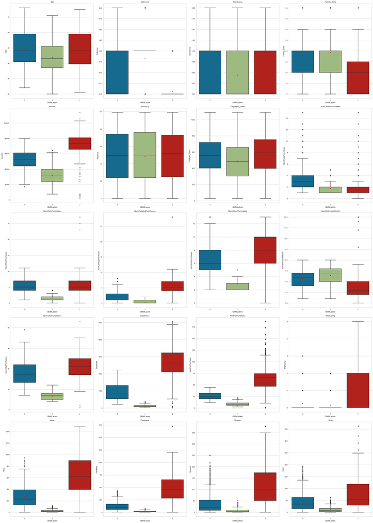

```python
# Create boxplot for each of the variables
all_col = col_for_box

plt.figure(figsize = (30, 50))

for i, variable in enumerate(all_col):
    plt.subplot(6, 4, i + 1)

    sns.boxplot(y=data[variable], x=data['GMMLabels'],showmeans=True)

    plt.tight_layout()

    plt.title(variable)

plt.show()
```

### **Characteristics of each cluster**

**Cluster 0: 706 customers (32%)**

- Discount sensitive buyers

**Summary for cluster 0: Discount sensitive loyalty customers**

**Cluster 1: 797 customers (36%)**

- Low spending customers
- Lowest income group
- Highest web visits per month

**Summary for cluster 1: Low Value**

**Cluster 2: 723 customers (33%)**

- Highest expenditure, income and number of purchase
- Highest campaign conversion

**Summary for cluster 2: High Value - High Frequency buyers who respond to campaigns**

**GMM doesn't give us unique and insightful customer profile. It groups all the high value customers into one group and separates the other two by low spending low income and discount sensitive customers who are likely to buyer if there is a deal**

```python
# Dropping labels we got from DBSCAN since we will be using PCA data for prediction
# Hint: Use axis=1 and inplace=True
data_pca.drop('GMMLabels', axis = 1, inplace = True)
data.drop('GMMLabels', axis = 1, inplace = True)
```